# Exploratory Data Analysis

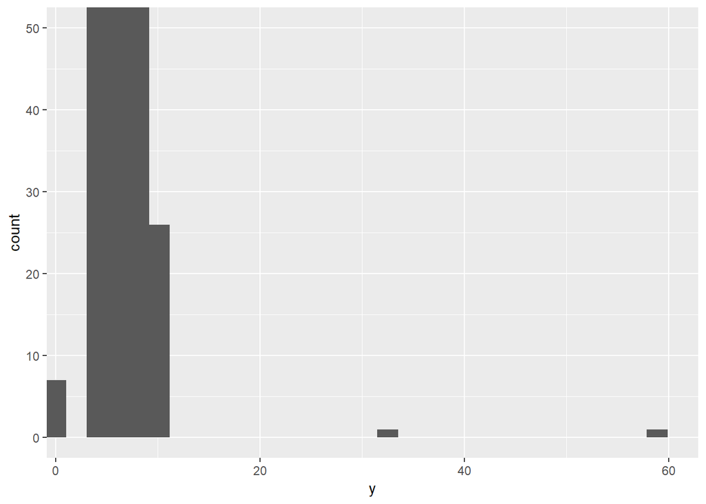

```r
# Also note how xlim and ylim inside coord_cartesian don't exclude the data
diamonds %>%
  ggplot(aes(y)) +
  geom_histogram(bins = 30) +
  coord_cartesian(xlim = c(2, 60), ylim = c(0, 50))
```

## Missing Values If you’ve encountered unusual values in your dataset, and simply want to move on to the rest of your analysis, you have two options. 1. Drop the entire row with the strange values: 2. Instead, we can replace the unusual values with missing values. The easiest way to do this is to use mutate() to replace the variable with a modified copy. You can use the ifelse() function to replace unusual values with NA:

# 7.4.1 Exercises for Missing Values

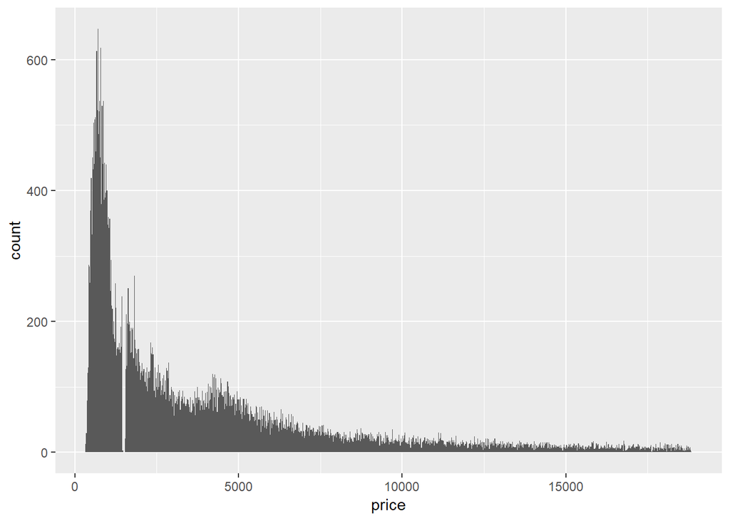

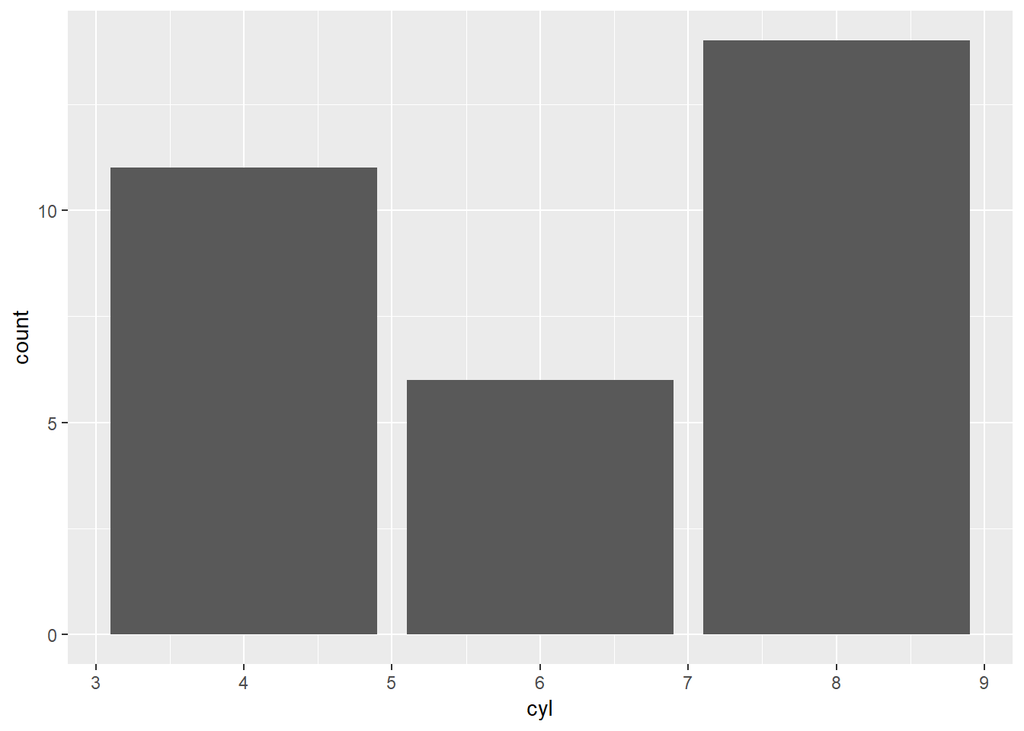

## Covariation If variation describes the behavior within a variable, covariation describes the behavior between variables. Covariation is the tendency for the values of two or more variables to vary together in a related way. The best way to spot covariation is to visualise the relationship between two or more variables.

# 7.5.1.1 Exercises for Covariation - A categorical and continuous variable

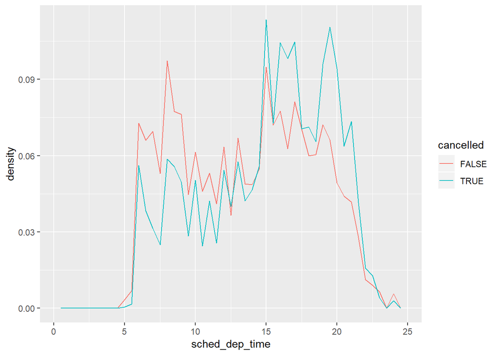

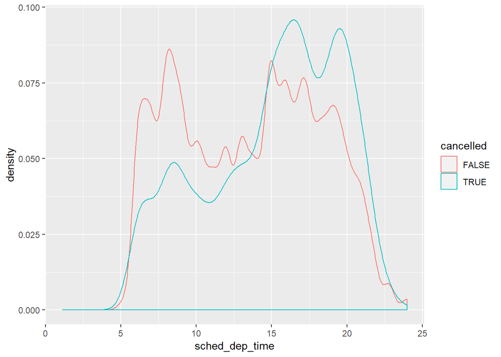

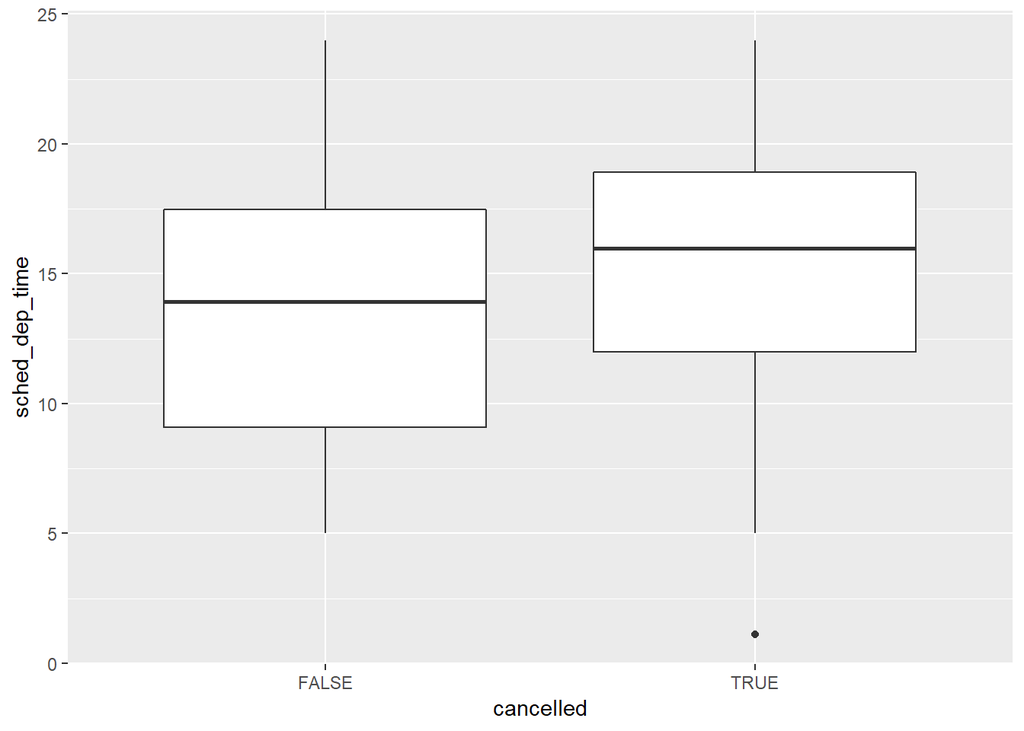

```
## lm(formula = price ~ ., data = diamonds)
##             coef.est coef.se  t value  Pr(>|t|)
## (Intercept)  5753.76   396.63    14.51     0.00
## carat       11256.98    48.63   231.49     0.00
## cut.L         584.46    22.48    26.00     0.00
## cut.Q        -301.91    17.99   -16.78     0.00
## cut.C         148.03    15.48     9.56     0.00
## cut^4         -20.79    12.38    -1.68     0.09
## color.L     -1952.16    17.34  -112.57     0.00
## color.Q      -672.05    15.78   -42.60     0.00
## color.C      -165.28    14.72   -11.22     0.00
## color^4        38.20    13.53     2.82     0.00
## color^5       -95.79    12.78    -7.50     0.00
## color^6       -48.47    11.61    -4.17     0.00
## clarity.L    4097.43    30.26   135.41     0.00
## clarity.Q   -1925.00    28.23   -68.20     0.00
## clarity.C     982.20    24.15    40.67     0.00
## clarity^4    -364.92    19.29   -18.92     0.00
## clarity^5     233.56    15.75    14.83     0.00
## clarity^6       6.88    13.72     0.50     0.62
## clarity^7      90.64    12.10     7.49     0.00
## depth         -63.81     4.53   -14.07     0.00
## table         -26.47     2.91    -9.09     0.00
## x           -1008.26    32.90   -30.65     0.00
## y               9.61    19.33     0.50     0.62
## z             -50.12    33.49    -1.50     0.13
## ---
## n = 53940, k = 24
## residual sd = 1130.09, R-Squared = 0.92
```

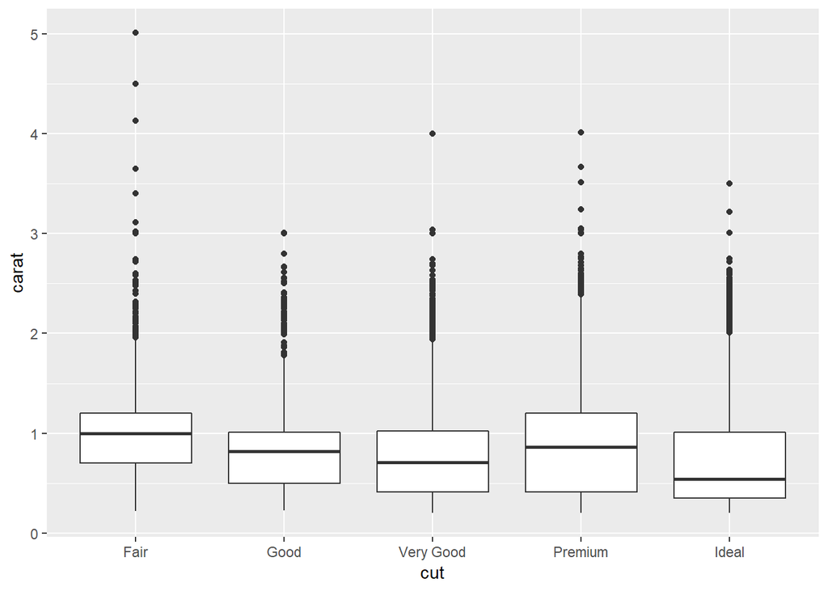

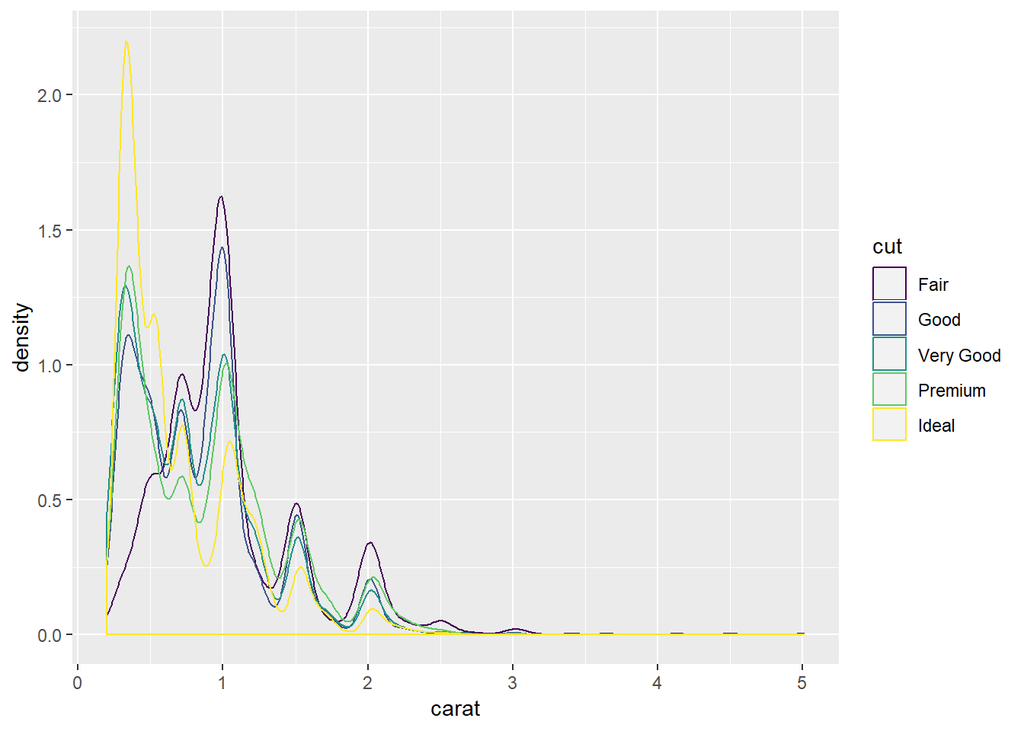

```
## # A tibble: 5 x 2
##   cut       `cor(carat, price)`
##   <ord>                   <dbl>
## 1 Fair                    0.859
## 2 Good                    0.922
## 3 Very Good               0.926
## 4 Premium                 0.925
## 5 Ideal                   0.931
```

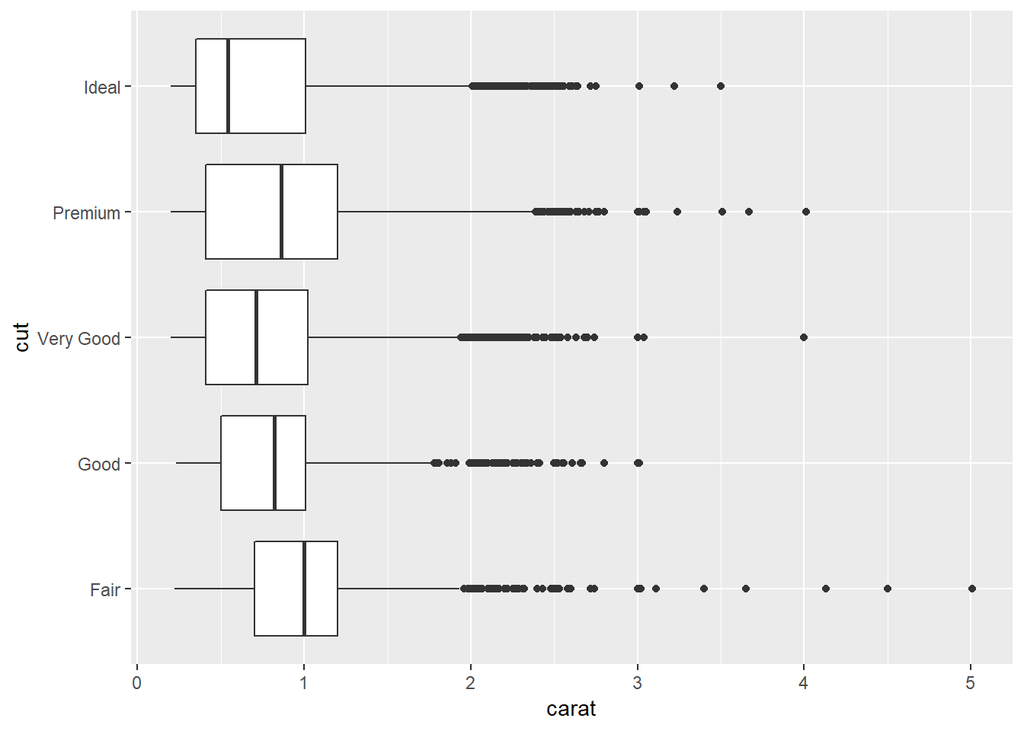

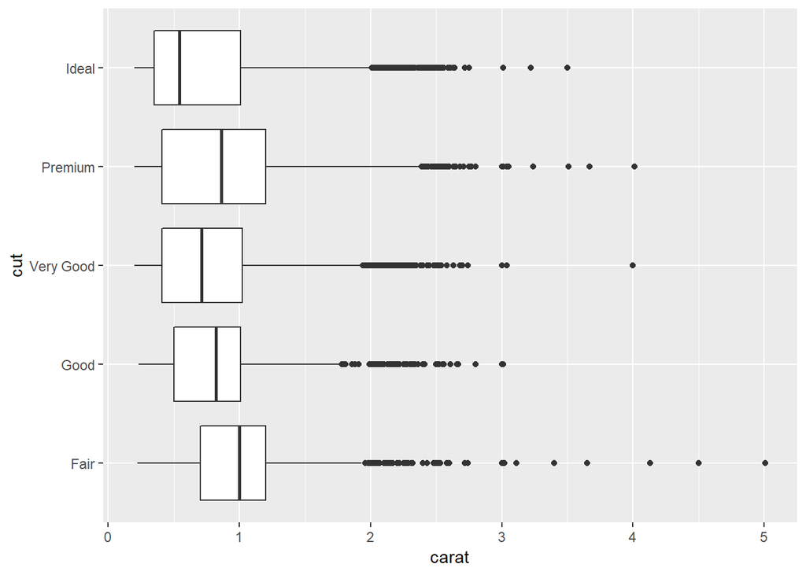

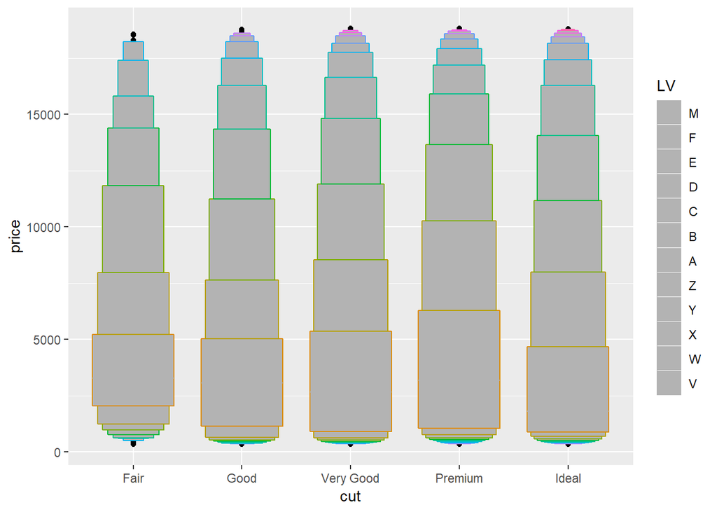

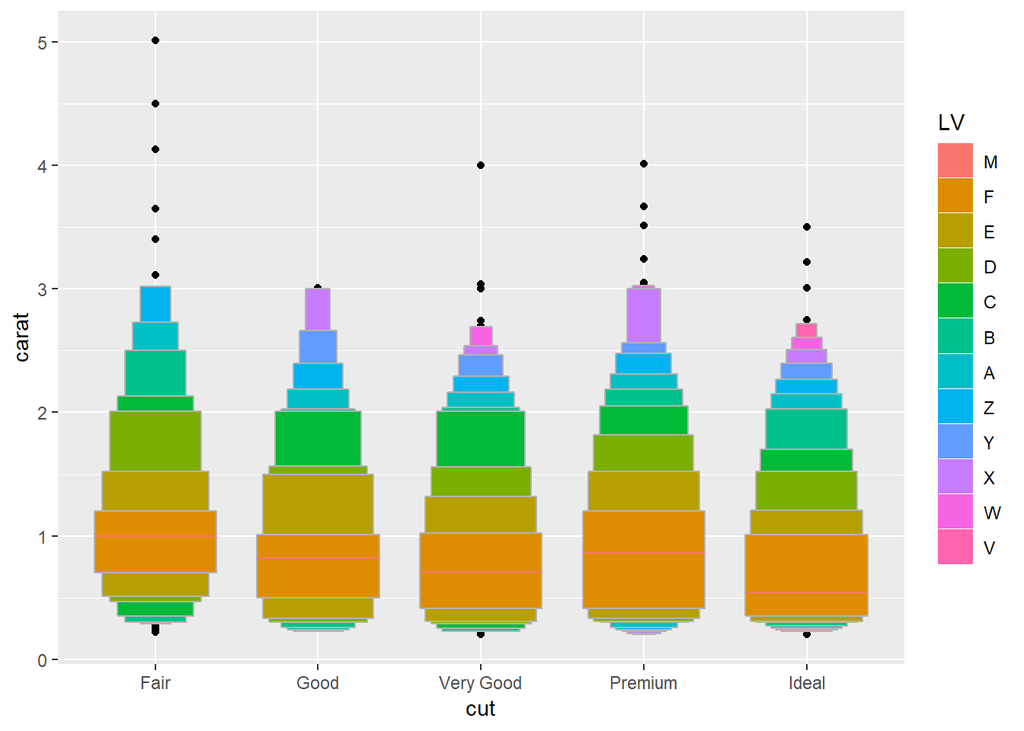

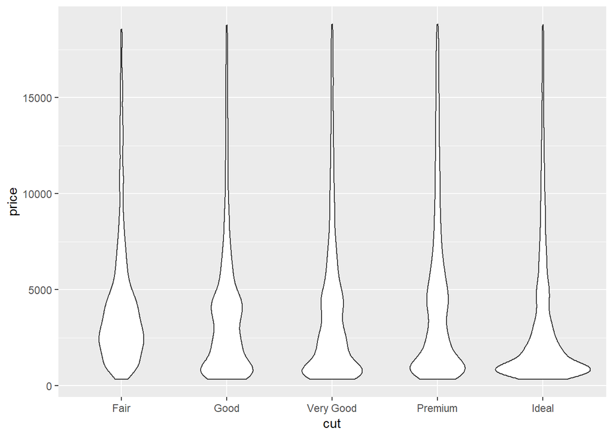

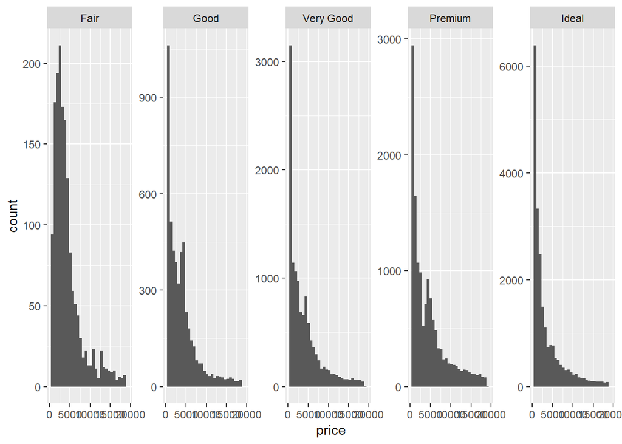

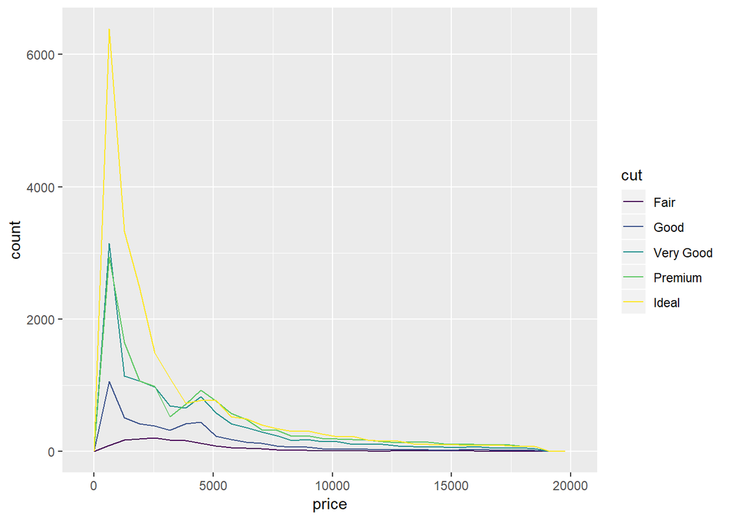

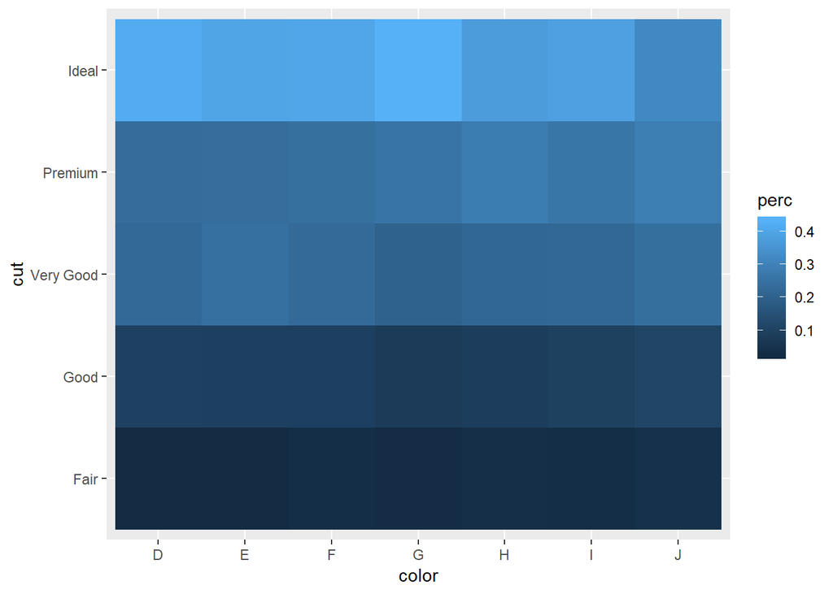

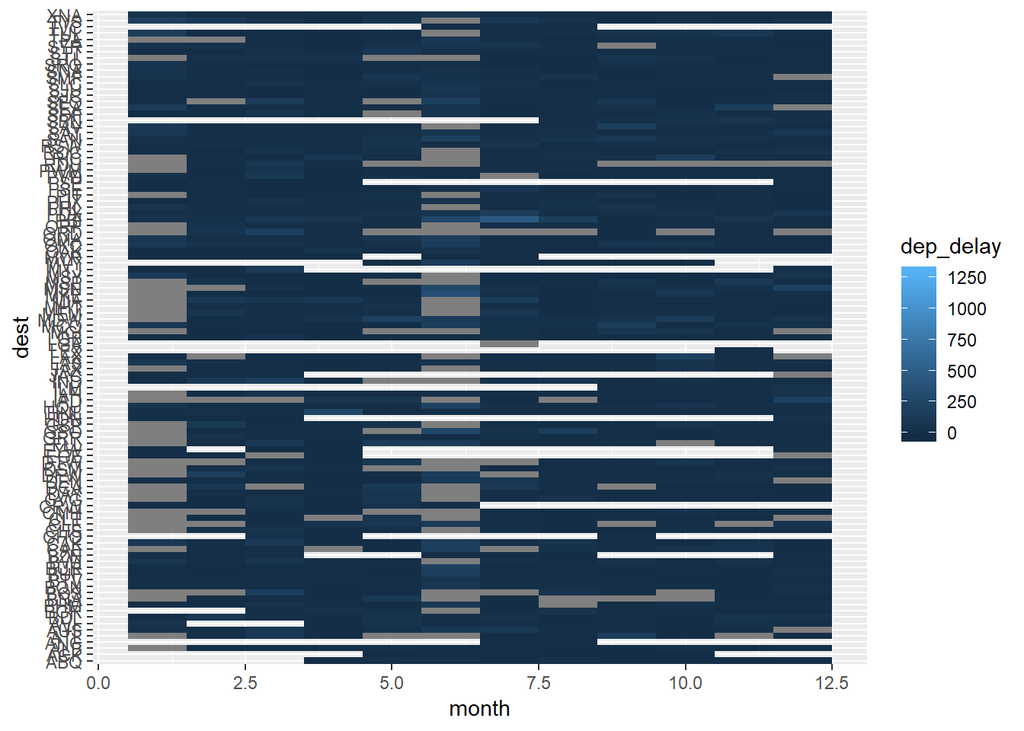

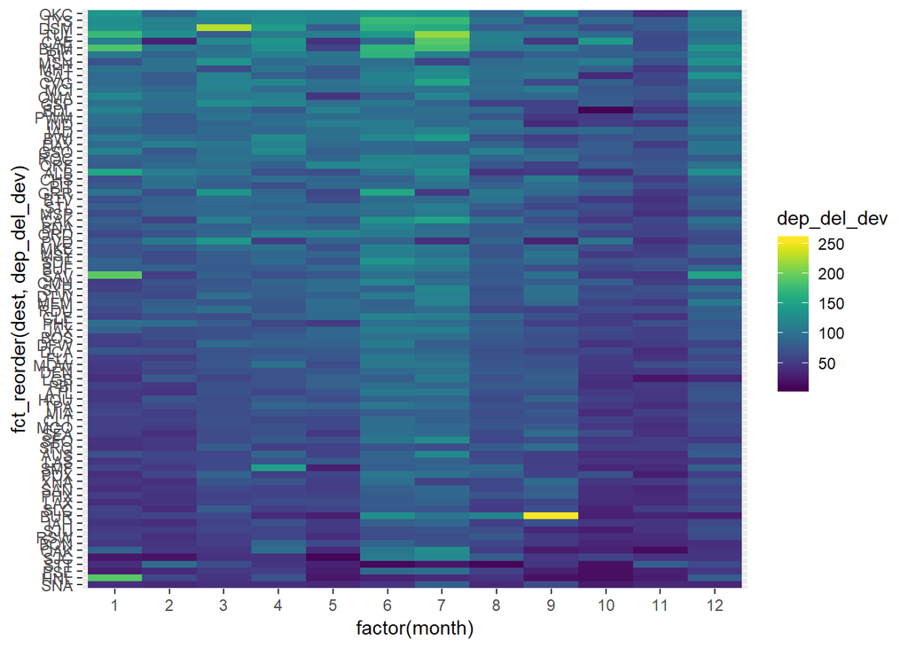

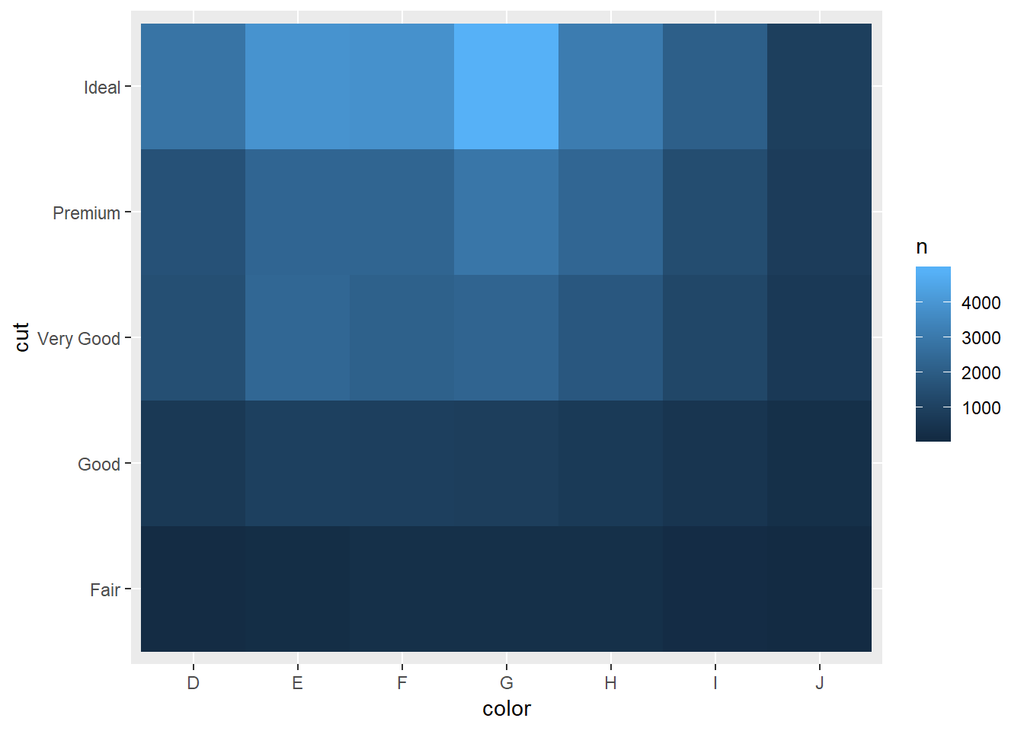